# Grup I · Imidazole glycerol phosphate synthase subunit HisF

Gerard Pañach, Ester Forés, Clara Alabau, Txell Cassases, Estel Àlvarez

2026-3-24

# **Pràctica 1. Relacions estructura-funció de proteïnes: Imidazole glycerol phosphate synthase subunit HisF**

### Grup I: Gerard Pañach, Ester Forés, Clara Alabau, Txell Cassases, Estel Àlvarez

## Índex

1. Introducció a la proteïna
2. Estructura
3. Funció
4. Treball amb l’aplicació ChimeraX
   - Estructures secundàries
   - Estructures supersecundàries
   - Estructura terciària
   - Centre actiu
   - Funció de la proteïna
   - Modificacions post-translacionals
   - Relació seqüència-estructura-funció
5. Bibliografia

## Introducció a la proteïna

**Nom de la proteïna:** Imidazole glycerol phosphate synthase subunit HisF

**Organisme:** thermotoga maritima

**Codi UNIPROT:** WP_004080486

**Gen:** hisF

**Aa:** 253

**Classificació EC:** EC:4.3.2.10

### Estructura:

Codi PDB: pdb_00008s8s

La proteïna està ben caracteritzada estructuralment al PDB amb múltiples entrades. Entre elles, 8S8S és l’opció òptima per continuar el treball perquè maximitza la qualitat estructural sense perdre informació de seqüència.

### Funció:

L’enzim està involucrat a la biosíntesi d’histidina, així com a la biosíntesi de nucleòtids de purina. Els enzims d’arquees i bacteris són heterodimèrics. Un component de glutaminasa (cf. EC 3.5.1.2, glutaminasa) produeix una molècula d’amoníac que es transfereix per un túnel de 25 Å a un component de ciclasa, que l’afegeix a l’anell d’imidazol, cosa que porta a la lisi de la molècula ia la ciclificació d’un. La subunitat de glutminasa només està activa dins el complex dimèric. En fongs i plantes, les dues subunitats es combinen en un sol polipèptid.

## Treball amb l’aplicació ChimeraX

### Estructures secundàries

#### **Detecteu les diferents estructures secundàries de la proteïna i determineu-ne el tipus (fulles, hèlix, llaços i les seves diferents variants). Mireu de descriure amb un cert detall els diferents tipus d’interaccions que podeu trobar dins aquestes estructures secundàries (mostreu els ponts d’hidrogen interns d’aquestes estructures secundàries).**

La subunitat HisF de la imidazole‑glycerol‑phosphate synthase està formada per una única cadena polipeptídica. Aquesta cadena presenta una estructura secundària ben definida, composta principalment per hèlixs α, làmines β i llaços o girs, elements que contribueixen de manera essencial a l’estabilitat del seu plegament en barril TIM i a la seva funció catalítica.

Les **hèlixs α** es formen quan la cadena polipeptídica s’enrotlla sobre si mateixa. Els ponts d’hidrogen (línies discontínues grogues) es formen de manera intercatenària entre l’oxigen del grup carbonil d’un aminoàciid i l’hidrogen del grup amino de l’aminoàcid situat quatre posicions més endavant, fet que aporta rigidesa i estabilitat a l’estructura.

Les **làmines β** constitueixen una altra part essencial, la direcció de la fletxa indica el sentit de la cadena. Els ponts d’Hidrogen són intercatenaris. Poden ser paral.leles (les cadenes van en el mateix sentit) o antiparal.leles (les cadenes van en sentis oposats, solen ser més estables), i formen el nucli estructural del plegament.

Els **girs i llaços** connecten les hèlixs α i les làmines β, proporcionant la flexibilitat necessària perquè la proteïna pugui dur a terme els seus canvis conformacionals durant la catàlisi. Aquestes regions, més flexibles que els elements regulars d’estructura secundària, poden estabilitzar els canvis de direcció mitjançant ponts d’hidrogen amb l’aigua o amb altres parts de la proteïna, contribuint així al plegament i a la dinàmica funcional de l’enzim.

Els **ponts d’hidrogen** estabilitzen l’estructura de la proteïna. En les hèlixs α i les làmines β mantenen la seva forma característica, mentre que en els girs i llaços ajuden a fixar els canvis de direcció i aporten flexibilitat.

El conjunt d’hèlixs α, làmines β i llaços, amb els ponts d’hidrogen ajuden a estabilitzar i confereix a la subunitat HisF una elevada estabilitat estructural i la flexibilitat necessària per dur a terme la seva funció catalítica dins del complex ImGPS.

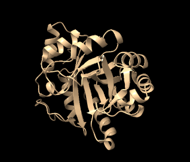

**Figura 1.** Imatge de HisF amb el programa ChimeraX amb una única cadena polipeptídica

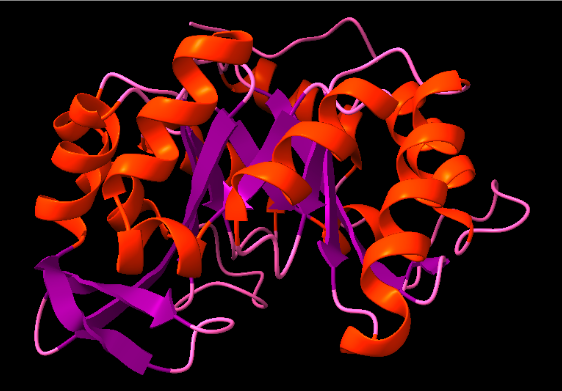

**Figura 2.** Imatge de la cadena polipeptídica de HisF. On en color taronja es veuen les hèlix α, en lila les fulles β i en rosa els llaços.

### Estructures supersecundàries

#### **Podeu detectar-hi motius d’estructura supersecundària? Mostreu les interaccions (ponts d’hidrogen, van der Waals) entre els diferents elements que constitueixen aquestes estructures supersecundàries.**

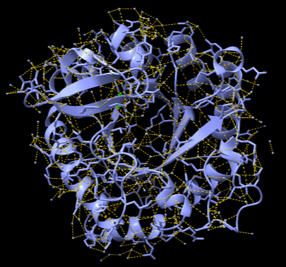

**Figura 3.** Imatge mostrant els ponts d’hidrogen d’aquesta estructura secundària amb color groc.

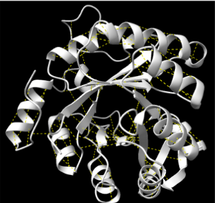

**Figura 4_a.** Ponts d’hidrogen (groc) estabilitzant làmines beta, coils i hèlixs alfa.

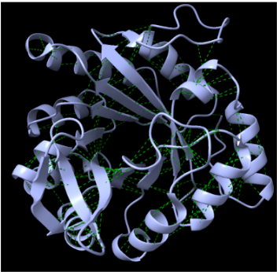

**Figura 4_b.** Interaccions de van der Waals (verd).

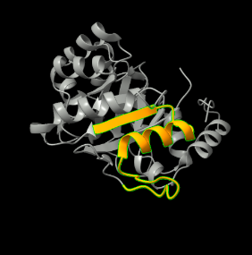

**Figura 4_c.**Motiu beta-alpha-beta.

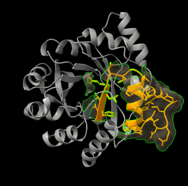

**Figura 4_d.**TIM barrel.

En l’estructura de la subunitat HisF es poden identificar diversos motius supersecundaris formats per la combinació d’hèlixs α i làmines β. Entre aquests destaca el motiu β‑α‑β, on una làmina β es connecta amb una hèlix α mitjançant un llaç, contribuint a l’organització del barril TIM. També s’observen β‑hairpins, formats per dues cadenes de làmina unides per un gir curt, que reforcen el nucli central de la proteïna. Aquestes estructures es mantenen gràcies a ponts d’hidrogen entre les cadenes de les làmines β i als ponts d’hidrogen interns de les hèlixs α, mentre que les interaccions de van der Waals entre les cadenes laterals afavoreixen l’empaquetament compacte del nucli proteic.

A la imatge 4_d podem veure en color groc, una de les unitats repetitives que conformen l’arquitectura de barril TIM (TIM barrel), on s’observa la connexió entre una làmina beta i una hèlix alpha. La superfície representada en gris fosc (trensparent)evidencia l’empaquetament hidrofòbic del nucli proteic, fonamentat en interaccions de Van der Waals entre les cadenes laterals de les estructures secundàries, essent aquest motiu estructural el responsable de l’estabilitat i la rigidesa necessàries per a la funció catalítica de l’enzim.

### Estructura terciària

#### **L’estructura terciària de la proteïna, a quin tipus de plegament correspon? Per a l’estudi dels dominis i de la família estructural, useu preferentment CATH i/o ECOD, perquè són recursos més actius per a classificació de dominis i relacions evolutives. Podeu usar SCOPe com a recurs complementari o de contrast. Anoteu els codis i la jerarquia que obtingueu, i discutiu també l’estructura quaternària si escau.**

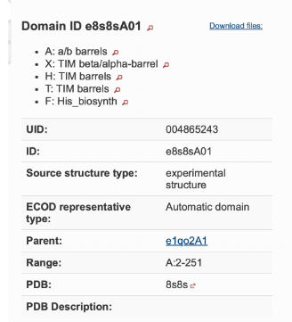

**Figura 5.** Jerarquia feta per ECOD per al domini e8s8sA01

La jerarquia ECOD per al domini e8s8sA01 (cadena A, residus 2-251) és molt clara:

**Discussió del plegament (Estructura Terciària):**

Si busquem el codi PDB **8S8S** a CATH, la jerarquia corresponent seria:

- **C (Class):** 3 (Alpha Beta).
- **A (Architecture):** 3.20 (Alpha-Beta Barrel).
- **T (Topology):** 3.20.20 (TIM Barrel).
- **H (Homologous Superfamily):** 3.20.20.120 (Aldolase).

### Centre actiu

**Identifiqueu el centre actiu de la proteïna. Quins residus són rellevants, segons la literatura? L’estructura que heu explorat inclou algun substrat o inhibidor? Podeu descriure les interaccions entre els residus del centre actiu i, eventualment, entre aquests residus i el possible substrat o inhibidor, com ara ponts d’hidrogen, interaccions de van der Waals o càrregues?**

El centre actiu de l’enzim HisF de Thermotoga maritima es localitza a l’extrem C-terminal del seu barril TIM, concretament en una cavitat formada pels bucles que connecten les làmines beta amb les hèlixs alpha, on s’allotja un complex mecanisme de catàlisi i unió; aquest espai conté quatre residus fonamentals (Asp11, His228, Asp130 i His178) que configuren un doble sistema de relleu de protons essencial per a la ciclació del substrat, a més de residus com l’Arg5, la Lys19 i la Thr164 que actuen com a ancoratges electrostàtics per als grups fosfat del PRFAR, permetent que el substrat s’estabilitzi mitjançant una xarxa de ponts d’hidrogen amb aspartats i histidines, interaccions de càrrega amb aminoàcids positius i forces de Van der Waals que asseguren un encaix induït perfecte dins la cavitat hidrofòbica de l’enzim.

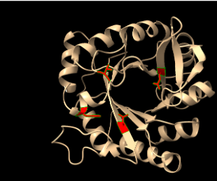

**Figura 6_a.** Residus del centre actiu com Asp 11 o His228.

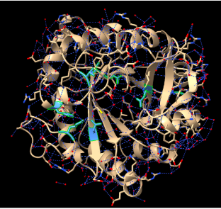

**Figura 6_b.** Xarxa d’estabilització i centre actiu de l’HisF.

### Funció de la proteïna

#### **Cerqueu informació sobre la funció que fa aquesta proteïna. Si es tracta d’un enzim, podeu mostrar i explicar el mecanisme detallat de la reacció que catalitza.**

L’IGPS catalitza la conversió de PRFAR i glutamina a IGP, AICAR i glutamat. La subunitat HisF catalitza l’activitat de ciclació que produeix IGP i AICAR a partir de PRFAR utilitzant l’amoníac proporcionat per la subunitat HisH.

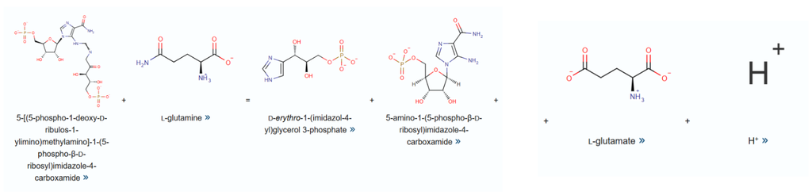

**Figura 7.**Conversió de PRFAR i glutamina a IGP, AICAR i glutamat.

### Modificacions post-translacionals

#### **Cerqueu informació sobre modificacions post-translacionals que es coneguin que afecten la proteïna o bé proteïnes similars. Identifiqueu els residus que podrien ser-ne diana.**

Les modificacions post-traduccionals (PTMs) són molt importants per regular l’activitat i l’estabilitat de les proteïnes. En el cas de la subunitat HisF de la IGP sintasa, no hi ha gaires modificacions descrites de manera específica, però es poden inferir a partir del que s’observa en altres enzims metabòlics similars.

Les modificacions més probables inclouen la fosforilació, que pot regular l’activitat enzimàtica, i l’acetilació, molt habitual en enzims del metabolisme, que pot influir en la seva funció. També es poden donar oxidacions en residus sensibles, així com, en menor mesura, metilacions o ubiquitinacions. Pel que fa als residus implicats, la fosforilació sol produir-se principalment en serines, treonines i tirosines. La lisina és clau per a processos com l’acetilació i la ubiquitinació. La cisteïna pot patir oxidacions relacionades amb l’estat redox de la cèl·lula. A més, la histidina també podria ser modificada, tenint en compte la seva importància en el centre actiu de molts enzims.

En una proteïna com HisF (253 aminoàcids), és probable que hi hagi diversos residus susceptibles de modificació al llarg de la seqüència, especialment lisines, serines, treonines i cisteïnes, que podrien actuar com a punts de regulació de l’activitat enzimàtica.

### Relació seqüència-estructura-funció

#### **Relació seqüència-estructura-funció: com relacionaríeu l’estructura que heu analitzat amb la funció de la proteïna? Quins elements estructurals participen en aquesta funció? Quins residus, en concret, són claus per a la funció? Cerqueu eventuals variants de la proteïna que tinguin implicacions funcionals i comenteu-ne els efectes a nivell molecular**

La subunitat HisF de Thermotoga maritima funciona com un barril rígid de tipus TIM que li permet resistir temperatures extremes i, gràcies a un túnel intern de 25 Å, canalitza l’amoníac de forma segura cap al seu centre actiu per fabricar histidina. Aquest centre actiu, situat al final de les làmines, utilitza uns “relleus” de protons formats pels parells Asp11-His228 i Asp130-His178 per completar la reacció. La importància d’aquesta estructura es veu en les mutacions: si canviem els aspartats clau per alanines (D130A, D11A), l’enzim perd la seva capacitat química tot i mantenir la seva forma. Si les mutacions afecten les zones de contacte amb l’altra subunitat (com Arg5 o Lys19), l’amoníac s’escapa pel camí i la feina es torna molt ineficient. Finalment, si s’altera el nucli interior de la proteïna, el barril perd la seva solidesa i es desmunta amb la calor. En definitiva, la seqüència està optimitzada per garantir que l’enzim mantingui la seva forma i pugui moure els protons amb precisió, assegurant que la síntesi funcioni correctament en l’ambient termòfil on viu l’organisme.

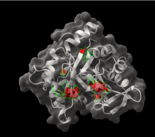

**Figura 8.** Canal intern i centre actiu de l’HisF.

A la figura 8 tenim la representació en superfície semitransparent que permet observar el túnel intern de 25 Å que travessa el barril TIM, facilitant el transport segur de l’amoníac. Els residus marcats en vermell identifiquen el centre actiu a l’extrem del canal, on es produeix la catàlisi essencial per a la biosíntesi d’histidina, demostrant la integració entre l’estructura interna i la funció enzimàtica.

## Bibliografia

SCOPe: Structural Classification of Proteins — extended. Release 2.08 (updated 2023-01-06, stable release September 2021). (n.d.). Berkeley.edu. Retrieved April 13, 2026, from https://scop.berkeley.edu/

UniProt. (n.d.). UniProt. Retrieved April 13, 2026, from https://www.uniprot.org/uniprotkb/O29439/entry

InterPro. (n.d.). Ebi.ac.uk. Retrieved April 13, 2026, from https://www.ebi.ac.uk/interpro/entry/InterPro/IPR010139/

CATH: Protein structure classification database at UCL. (n.d.). Cathdb.Info. Retrieved April 13, 2026, from https://www.cathdb.info/

Evolutionary classification of protein domains. (n.d.). Swmed.edu. Retrieved April 13, 2026, from http://prodata.swmed.edu/ecod/

Wurm, J. P., Sung, S., Kneuttinger, A. C., Hupfeld, E., Sterner, R., Wilmanns, M., & Sprangers, R. (2021). Molecular basis for the allosteric activation mechanism of the heterodimeric imidazole glycerol phosphate synthase complex. Nature Communications, 12(1), 2748. https://doi.org/10.1038/s41467-021-22968-6